# TO 628 Final Project: Spotify Hits Data

Team 8: MBAi

4/9/2023

# 1 Intermediate Deliverable

## 1.1 Link to GitHub repo

https://github.com/sammysunnyshine/TO-628-Final-Project.git

## 1.2 Data Set Details

**The Spotify Hit Predictor Dataset: 2000-2009**

This data set includes songs on Spotify that were produced between Jan 01, 2000 and Dec 31, 2009. Each song has been scored across a number of variables; these scores are presented along with other details about the songs, such as duration, tempo, etc.

Variables:

- track: The Name of the track.
- artist: The Name of the Artist.
- uri: The resource identifier for the track.
- danceability: Danceability describes how suitable a track is for dancing based on a combination of musical elements including tempo, rhythm stability, beat strength, and overall regularity. A value of 0.0 is least danceable and 1.0 is most danceable.
- energy: Energy is a measure from 0.0 to 1.0 and represents a perceptual measure of intensity and activity. Typically, energetic tracks feel fast, loud, and noisy. For example, death metal has high energy, while a Bach prelude scores low on the scale. Perceptual features contributing to this attribute include dynamic range, perceived loudness, timbre, onset rate, and general entropy.
- key: The estimated overall key of the track. Integers map to pitches using standard Pitch Class notation. E.g. 0 = C, 1 = C?/D?, 2 = D, and so on. If no key was detected, the value is -1.
- loudness: The overall loudness of a track in decibels (dB). Loudness values are averaged across the entire track and are useful for comparing relative loudness of tracks. Loudness is the quality of a sound that is the primary psychological correlate of physical strength (amplitude). Values typical range between -60 and 0 db.
- mode: Mode indicates the modality (major or minor) of a track, the type of scale from which its melodic content is derived. Major is represented by 1 and minor is 0.
- speechiness: Speechiness detects the presence of spoken words in a track. The more exclusively speech-like the recording (e.g. talk show, audio book, poetry), the closer to 1.0 the attribute value. Values above 0.66 describe tracks that are probably made entirely of spoken words. Values between 0.33 and 0.66 describe tracks that may contain both music and speech, either in sections or layered, including such cases as rap music. Values below 0.33 most likely represent music and other non-speech-like tracks.
- acousticness: A confidence measure from 0.0 to 1.0 of whether the track is acoustic. 1.0 represents high confidence the track is acoustic. The distribution of values for this feature look like this:
- instrumentalness: Predicts whether a track contains no vocals. “Ooh” and “aah” sounds are treated as instrumental in this context. Rap or spoken word tracks are clearly “vocal”. The closer the instrumentalness value is to 1.0, the greater likelihood the track contains no vocal content. Values above 0.5 are intended to represent instrumental tracks, but confidence is higher as the value approaches 1.0. The distribution of values for this feature look like this:
- liveness: Detects the presence of an audience in the recording. Higher liveness values represent an increased probability that the track was performed live. A value above 0.8 provides strong likelihood that the track is live.
- valence: A measure from 0.0 to 1.0 describing the musical positiveness conveyed by a track. Tracks with high valence sound more positive (e.g. happy, cheerful, euphoric), while tracks with low valence sound more negative (e.g. sad, depressed, angry).
- tempo: The overall estimated tempo of a track in beats per minute (BPM). In musical terminology, tempo is the speed or pace of a given piece and derives directly from the average beat duration.
- duration_ms: The duration of the track in milliseconds.
- time_signature: An estimated overall time signature of a track. The time signature (meter) is a notational convention to specify how many beats are in each bar (or measure).
- chorus_hit: This the the author’s best estimate of when the chorus would start for the track. Its the timestamp of the start of the third section of the track. This feature was extracted from the data received by the API call for Audio Analysis of that particular track.
- sections: The number of sections the particular track has. This feature was extracted from the data received by the API call for Audio Analysis of that particular track.
- target: The target variable for the track. It can be either ‘0’ or ‘1’. ‘1’ implies that this song has featured in the weekly list (Issued by Billboards) of Hot-100 tracks in that decade at least once and is therefore a ‘hit’. ‘0’ Implies that the track is a ‘flop’.

## 1.3 Business Question

What makes a song turn into a “hit” or a “flop”? Our goal is to build a model that predicts which songs will be successful on Spotify, which serves as a proxy for the overall music market.

This will be extremely useful to artists, managers, producers, and all other parties who have stakes in launching new music. Our model will help identify what characteristics make a song successful, regardless of genre, and help evaluate existing songs and new songs in production. Why does this matter?

- Maximizing ROI: creators, their talent managers, and music labels can better prioritize to which songs they should allocate more resources, e.g. which songs to record music videos for and include in an album
- Artist development: music labels and talent managers can identify and develop emerging talent if they have early indications that their songs have a high potential to become hits
- Marketing strategies: Many artists are savvy marketers and strategically order and time song releases (e.g. Taylor Swift is well-known for that). A good prediction model could supplement their instincts and business acumen in their decision-making
- Streaming services and payment models: Given there have been ongoing discussions in the news cycle around payment models used by streaming services like Spotify and Apple Music, with the latter being criticized for inadequately compensating creators, prediction models for song’s success in the market could help open the door for alternative payment arrangements. Currently, a song could easily take $1K to produce, yet 100K streams could results in approx. $400 or less of a paycheck.

*Our model will be able to determine with a high level of confidence whether a song will be a “hit” or a “flop.”* Being able to predict if a song would be a hit can help stakeholders in the music industry make data-driven decisions, optimize their investments into new music and music videos, and ultimately increase revenue.

*Sources:* https://www.usatoday.com/story/life/2022/10/22/how-much-per-spotify-stream/8094437001/ https://dittomusic.com/en/blog/how-much-does-spotify-pay-per-stream/

## 1.4 Read and Clean Data

```r
spot <- read.csv("spotify_hits.csv")

spot$uri <- NULL

# Delete the tracks field because it's essentially individual IDs
spot$track <- NULL

# Deleting artist - too many unique values
spot$artist <- NULL

# There are no NA values
# There is no need to create factors

str(spot)
```

```
## 'data.frame':    5872 obs. of  16 variables:
##  $ danceability    : num  0.578 0.704 0.162 0.188 0.63 0.726 0.365 0.726 0.481 0.647 ...
##  $ energy          : num  0.471 0.854 0.836 0.994 0.764 0.837 0.922 0.631 0.786 0.324 ...
##  $ key             : int  4 10 9 4 2 11 1 11 10 7 ...
##  $ loudness        : num  -7.27 -5.48 -3.01 -3.75 -4.35 ...
##  $ mode            : int  1 0 1 1 1 0 1 0 1 1 ...
##  $ speechiness     : num  0.0289 0.183 0.0473 0.166 0.0275 0.0965 0.071 0.0334 0.0288 0.0377 ...
##  $ acousticness    : num  3.68e-01 1.85e-02 1.11e-04 7.39e-06 3.63e-01 3.73e-01 2.85e-03 2.20e-01 5.38e-02 3.54e-01 ...
##  $ instrumentalness: num  0 0 0.00457 0.0784 0 0.268 0 0 0 0 ...
##  $ liveness        : num  0.159 0.148 0.174 0.192 0.125 0.136 0.321 0.193 0.0759 0.115 ...
##  $ valence         : num  0.532 0.688 0.3 0.333 0.631 0.969 0.29 0.746 0.389 0.344 ...
##  $ tempo           : num  133 93 87 148 112 ...
##  $ duration_ms     : int  196707 242587 338893 255667 193760 192720 89427 239240 253640 314286 ...
##  $ time_signature  : int  4 4 4 4 4 4 4 4 4 3 ...
##  $ chorus_hit      : num  30.9 41.5 65.3 58.6 22.6 ...
##  $ sections        : int  13 10 13 9 10 10 4 10 11 16 ...
##  $ target          : int  1 1 0 0 1 0 0 1 1 0 ...
```

```r
summary(spot)
```

```
##   danceability        energy              key            loudness
##  Min.   :0.0588   Min.   :0.000348   Min.   : 0.000   Min.   :-47.327
##  1st Qu.:0.4160   1st Qu.:0.567000   1st Qu.: 2.000   1st Qu.: -8.315
##  Median :0.5560   Median :0.744000   Median : 5.000   Median : -6.042
##  Mean   :0.5429   Mean   :0.694511   Mean   : 5.276   Mean   : -7.449
##  3rd Qu.:0.6810   3rd Qu.:0.885000   3rd Qu.: 8.000   3rd Qu.: -4.562
##  Max.   :0.9860   Max.   :0.999000   Max.   :11.000   Max.   :  1.137
##       mode         speechiness       acousticness      instrumentalness
##  Min.   :0.0000   Min.   :0.02240   Min.   :0.000000   Min.   :0.0000000
##  1st Qu.:0.0000   1st Qu.:0.03617   1st Qu.:0.004553   1st Qu.:0.0000000
##  Median :1.0000   Median :0.05270   Median :0.060300   Median :0.0000218
##  Mean   :0.6451   Mean   :0.09236   Mean   :0.214374   Mean   :0.1509172
##  3rd Qu.:1.0000   3rd Qu.:0.10700   3rd Qu.:0.312000   3rd Qu.:0.0472750
##  Max.   :1.0000   Max.   :0.95000   Max.   :0.996000   Max.   :0.9980000
##     liveness         valence           tempo         duration_ms
##  Min.   :0.0193   Min.   :0.0000   Min.   : 46.76   Min.   :  15920
##  1st Qu.:0.0937   1st Qu.:0.2780   1st Qu.: 96.98   1st Qu.: 206813
##  Median :0.1310   Median :0.4860   Median :120.00   Median : 238006
##  Mean   :0.1961   Mean   :0.4823   Mean   :121.61   Mean   : 258171
##  3rd Qu.:0.2630   3rd Qu.:0.6870   3rd Qu.:141.50   3rd Qu.: 279160
##  Max.   :0.9870   Max.   :0.9820   Max.   :213.23   Max.   :4170227
##  time_signature    chorus_hit        sections          target
##  Min.   :0.000   Min.   :  0.00   Min.   :  1.00   Min.   :0.0
##  1st Qu.:4.000   1st Qu.: 27.51   1st Qu.:  9.00   1st Qu.:0.0
##  Median :4.000   Median : 36.04   Median : 10.00   Median :0.5
##  Mean   :3.914   Mean   : 40.73   Mean   : 11.06   Mean   :0.5
##  3rd Qu.:4.000   3rd Qu.: 47.89   3rd Qu.: 12.00   3rd Qu.:1.0
##  Max.   :5.000   Max.   :262.62   Max.   :169.00   Max.   :1.0
```

See code comments for details on cleaning. Dummy variables are not needed.

## 1.5 Randomize the Data Set

```r
spot_random <- spot[sample(1:nrow(spot)), ]
```

## 1.6 Normalize the Data

```r
normalize <- function(x) {
  return ((x - min(x)) / (max(x) - min(x)))
}

spot_norm <- as.data.frame(lapply(spot_random, normalize))
```

## 1.7 Split Test and Train

```r
set.seed(13090890)
test_set <- sample(1:nrow(spot_norm), 0.5*nrow(spot_norm))
spot_test <- spot_norm[test_set, ]
spot_train <- spot_norm[-test_set, ]
```

Created spot_test and spot_train with a 50/50 random sample.

## 1.8 Build Regression Model

```r
model_lr <- glm(target ~ ., family = "binomial", data = spot_train)
summary(model_lr)
```

```
##
## Call:
## glm(formula = target ~ ., family = "binomial", data = spot_train)
##
## Deviance Residuals:
##     Min       1Q   Median       3Q      Max
## -2.9364  -0.5132   0.1818   0.6648   3.7960
##
## Coefficients:
##                   Estimate Std. Error z value Pr(>|z|)
## (Intercept)      -17.22741    1.43441 -12.010  < 2e-16 ***
## danceability       5.40094    0.40760  13.251  < 2e-16 ***
## energy            -6.04097    0.50413 -11.983  < 2e-16 ***
## key                0.29488    0.15938   1.850  0.06430 .
## loudness          21.37402    1.54301  13.852  < 2e-16 ***
## mode               0.44232    0.11200   3.949 7.83e-05 ***
## speechiness       -0.09891    0.54728  -0.181  0.85658
## acousticness      -2.18075    0.29518  -7.388 1.49e-13 ***
## instrumentalness  -5.47877    0.47141 -11.622  < 2e-16 ***
## liveness          -0.67194    0.32538  -2.065  0.03892 *
## valence           -0.20972    0.27714  -0.757  0.44922
## tempo              0.30122    0.30831   0.977  0.32857
## duration_ms       -8.69476    5.05112  -1.721  0.08519 .
## time_signature     2.42905    0.87837   2.765  0.00569 **
## chorus_hit        -1.23135    0.79297  -1.553  0.12046
## sections          -0.22284    4.50285  -0.049  0.96053
## ---
## Signif. codes:  0 '***' 0.001 '**' 0.01 '*' 0.05 '.' 0.1 ' ' 1
##
## (Dispersion parameter for binomial family taken to be 1)
##
##     Null deviance: 4068.8  on 2935  degrees of freedom
## Residual deviance: 2318.6  on 2920  degrees of freedom
## AIC: 2350.6
##
## Number of Fisher Scoring iterations: 7
```

## 1.9 Predict Test Data

```r
spot_pred <- predict(model_lr, spot_test, type = "response")

summary(spot_pred)
```

```
##    Min. 1st Qu.  Median    Mean 3rd Qu.    Max.
##  0.0000  0.1167  0.5845  0.5000  0.8132  0.9951
```

```r
spot_bin_pred <- ifelse(spot_pred >= 0.5, 1, 0) # Given the data is relatively balanced, we use 50% threshold

table(spot_bin_pred)
```

```
## spot_bin_pred
##    0    1
## 1294 1642
```

## 1.10 Evaluate Model

```r
library(caret)
confusionMatrix(as.factor(spot_bin_pred), as.factor(spot_test$target), positive = "1")
```

```
## Confusion Matrix and Statistics
##
##           Reference
## Prediction    0    1
##          0 1124  170
##          1  376 1266
##
##                Accuracy : 0.814
##                  95% CI : (0.7995, 0.828)
##     No Information Rate : 0.5109
##     P-Value [Acc > NIR] : < 2.2e-16
##
##                   Kappa : 0.629
##
##  Mcnemar's Test P-Value : < 2.2e-16
##
##             Sensitivity : 0.8816
##             Specificity : 0.7493
##          Pos Pred Value : 0.7710
##          Neg Pred Value : 0.8686
##              Prevalence : 0.4891
##          Detection Rate : 0.4312
##    Detection Prevalence : 0.5593
##       Balanced Accuracy : 0.8155
##
##        'Positive' Class : 1
##
```

# 2 Final Deliverable

## 2.1 Flag and Split Popular Artists

```r
spot2 <- read.csv("spotify_hits.csv")
criteria <- read.csv("popular_artists.csv", header = FALSE)
criteria_vec <- as.character(criteria$V1)

# Explore top artists
head(sort(table(spot2$artist), decreasing = TRUE), 20)
```

```
##
##        Toby Keith     Rascal Flatts        Tim McGraw       Iron Maiden
##                27                24                24                23
##     Kenny Chesney     George Strait      Brad Paisley       Keith Urban
##                23                22                20                20
##      Alan Jackson    Britney Spears   Harry Belafonte     Brooks & Dunn
##                19                19                19                17
##            Nausea      Taylor Swift             Tenhi           Turisas
##                17                17                17                16
##          Lonestar Montgomery Gentry              P!nk            Eminem
##                15                15                15                14
```

```r
spot2$uri <- NULL

# Delete the tracks field because it's essentially individual IDs
spot2$track <- NULL

# Creating dummy variable to distinguish popular and lesser-known artists
spot2$artist_popularity <- ifelse(spot2$artist %in% criteria_vec, 1, 0)

# Deleting artist - too many unique values
spot2$artist <- NULL

# Split Popular and Lesser-Known Artists
spot_unknown <- spot2[spot2$artist_popularity == 0, ]
spot_popular <- spot2[spot2$artist_popularity == 1, ]

spot_unknown$artist_popularity <- NULL
spot_popular$artist_popularity <- NULL

str(spot_unknown)
```

```
## 'data.frame':    4840 obs. of  16 variables:
##  $ danceability    : num  0.704 0.162 0.188 0.63 0.726 0.365 0.647 0.787 0.491 0.455 ...
##  $ energy          : num  0.854 0.836 0.994 0.764 0.837 0.922 0.324 0.632 0.776 0.737 ...
##  $ key             : int  10 9 4 2 11 1 7 8 2 1 ...
##  $ loudness        : num  -5.48 -3.01 -3.75 -4.35 -7.22 ...
##  $ mode            : int  0 1 1 1 0 1 1 1 1 1 ...
##  $ speechiness     : num  0.183 0.0473 0.166 0.0275 0.0965 0.071 0.0377 0.137 0.0393 0.0272 ...
##  $ acousticness    : num  1.85e-02 1.11e-04 7.39e-06 3.63e-01 3.73e-01 2.85e-03 3.54e-01 1.03e-01 3.14e-01 1.14e-03 ...
##  $ instrumentalness: num  0.00 4.57e-03 7.84e-02 0.00 2.68e-01 0.00 0.00 6.78e-06 0.00 4.87e-04 ...
##  $ liveness        : num  0.148 0.174 0.192 0.125 0.136 0.321 0.115 0.388 0.146 0.195 ...
##  $ valence         : num  0.688 0.3 0.333 0.631 0.969 0.29 0.344 0.612 0.428 0.206 ...
##  $ tempo           : num  93 87 148 112 135 ...
##  $ duration_ms     : int  242587 338893 255667 193760 192720 89427 314286 198173 202547 224053 ...
##  $ time_signature  : int  4 4 4 4 4 4 3 4 4 4 ...
##  $ chorus_hit      : num  41.5 65.3 58.6 22.6 28.3 ...
##  $ sections        : int  10 13 9 10 10 4 16 9 9 9 ...
##  $ target          : int  1 0 0 1 0 0 0 1 1 0 ...
```

```r
summary(spot_unknown)
```

```
##   danceability        energy              key            loudness
##  Min.   :0.0588   Min.   :0.000348   Min.   : 0.000   Min.   :-47.327
##  1st Qu.:0.3970   1st Qu.:0.555000   1st Qu.: 2.000   1st Qu.: -8.653
##  Median :0.5450   Median :0.744000   Median : 5.000   Median : -6.183
##  Mean   :0.5337   Mean   :0.691432   Mean   : 5.291   Mean   : -7.741
##  3rd Qu.:0.6780   3rd Qu.:0.892000   3rd Qu.: 8.000   3rd Qu.: -4.659
##  Max.   :0.9860   Max.   :0.999000   Max.   :11.000   Max.   :  1.137
##       mode         speechiness       acousticness     instrumentalness
##  Min.   :0.0000   Min.   :0.02240   Min.   :0.00000   Min.   :0.0000000
##  1st Qu.:0.0000   1st Qu.:0.03760   1st Qu.:0.00351   1st Qu.:0.0000000
##  Median :1.0000   Median :0.05580   Median :0.05805   Median :0.0000612
##  Mean   :0.6308   Mean   :0.09637   Mean   :0.22264   Mean   :0.1743082
##  3rd Qu.:1.0000   3rd Qu.:0.11300   3rd Qu.:0.33800   3rd Qu.:0.1210000
##  Max.   :1.0000   Max.   :0.95000   Max.   :0.99600   Max.   :0.9980000
##     liveness         valence           tempo         duration_ms
##  Min.   :0.0209   Min.   :0.0000   Min.   : 46.76   Min.   :  15920
##  1st Qu.:0.0937   1st Qu.:0.2670   1st Qu.: 97.02   1st Qu.: 206000
##  Median :0.1300   Median :0.4790   Median :120.02   Median : 238854
##  Mean   :0.1963   Mean   :0.4747   Mean   :121.94   Mean   : 261216
##  3rd Qu.:0.2630   3rd Qu.:0.6810   3rd Qu.:141.98   3rd Qu.: 283424
##  Max.   :0.9870   Max.   :0.9820   Max.   :210.86   Max.   :4170227
##  time_signature    chorus_hit        sections          target
##  Min.   :0.000   Min.   :  0.00   Min.   :  1.00   Min.   :0.0000
##  1st Qu.:4.000   1st Qu.: 27.67   1st Qu.:  9.00   1st Qu.:0.0000
##  Median :4.000   Median : 36.26   Median : 10.00   Median :0.0000
##  Mean   :3.905   Mean   : 41.04   Mean   : 11.17   Mean   :0.4124
##  3rd Qu.:4.000   3rd Qu.: 48.18   3rd Qu.: 13.00   3rd Qu.:1.0000
##  Max.   :5.000   Max.   :219.64   Max.   :169.00   Max.   :1.0000
```

Popular artists are popular for a variety of reasons that are entirely separate from this data set – marketing, exposure, appearance, connections, etc. – that it does not make sense to run a predictive model on the data we have. However, among *unknown* artists who have limited existing support, it is far more important to predict who will hit and who will flop. This group of artists has the highest volatility but potentially the highest payoff, so we will focus here.

## 2.2 Randomize the Unknown Artists

```r
spot_uk_random <- spot_unknown[sample(1:nrow(spot_unknown)), ]
```

## 2.3 Normalize the Data

```r
normalize <- function(x) {
  return ((x - min(x)) / (max(x) - min(x)))
}

spot_uk_norm <- as.data.frame(lapply(spot_uk_random, normalize))

summary(spot_uk_norm)
```

```
##   danceability        energy            key            loudness
##  Min.   :0.0000   Min.   :0.0000   Min.   :0.0000   Min.   :0.0000
##  1st Qu.:0.3648   1st Qu.:0.5554   1st Qu.:0.1818   1st Qu.:0.7980
##  Median :0.5244   Median :0.7447   Median :0.4545   Median :0.8490
##  Mean   :0.5122   Mean   :0.6920   Mean   :0.4810   Mean   :0.8168
##  3rd Qu.:0.6678   3rd Qu.:0.8929   3rd Qu.:0.7273   3rd Qu.:0.8804
##  Max.   :1.0000   Max.   :1.0000   Max.   :1.0000   Max.   :1.0000
##       mode         speechiness       acousticness      instrumentalness
##  Min.   :0.0000   Min.   :0.00000   Min.   :0.000000   Min.   :0.0000000
##  1st Qu.:0.0000   1st Qu.:0.01639   1st Qu.:0.003524   1st Qu.:0.0000000
##  Median :1.0000   Median :0.03601   Median :0.058283   Median :0.0000614
##  Mean   :0.6308   Mean   :0.07974   Mean   :0.223532   Mean   :0.1746575
##  3rd Qu.:1.0000   3rd Qu.:0.09767   3rd Qu.:0.339357   3rd Qu.:0.1212425
##  Max.   :1.0000   Max.   :1.00000   Max.   :1.000000   Max.   :1.0000000
##     liveness          valence           tempo         duration_ms
##  Min.   :0.00000   Min.   :0.0000   Min.   :0.0000   Min.   :0.00000
##  1st Qu.:0.07535   1st Qu.:0.2719   1st Qu.:0.3063   1st Qu.:0.04575
##  Median :0.11293   Median :0.4878   Median :0.4464   Median :0.05366
##  Mean   :0.18160   Mean   :0.4834   Mean   :0.4582   Mean   :0.05905
##  3rd Qu.:0.25060   3rd Qu.:0.6935   3rd Qu.:0.5803   3rd Qu.:0.06439
##  Max.   :1.00000   Max.   :1.0000   Max.   :1.0000   Max.   :1.00000
##  time_signature     chorus_hit        sections           target
##  Min.   :0.0000   Min.   :0.0000   Min.   :0.00000   Min.   :0.0000
##  1st Qu.:0.8000   1st Qu.:0.1260   1st Qu.:0.04762   1st Qu.:0.0000
##  Median :0.8000   Median :0.1651   Median :0.05357   Median :0.0000
##  Mean   :0.7809   Mean   :0.1869   Mean   :0.06055   Mean   :0.4124
##  3rd Qu.:0.8000   3rd Qu.:0.2194   3rd Qu.:0.07143   3rd Qu.:1.0000
##  Max.   :1.0000   Max.   :1.0000   Max.   :1.00000   Max.   :1.0000
```

## 2.4 Split Test and Train

```r
set.seed(13090890)
test_set_uk <- sample(1:nrow(spot_uk_norm), 0.5*nrow(spot_uk_norm))
spot_test_uk <- spot_uk_norm[test_set_uk, ]
spot_train_uk <- spot_uk_norm[-test_set_uk, ]

summary(spot_test_uk)
```

```
##   danceability        energy               key            loudness
##  Min.   :0.0000   Min.   :0.0006349   Min.   :0.0000   Min.   :0.0000
##  1st Qu.:0.3604   1st Qu.:0.5624101   1st Qu.:0.1818   1st Qu.:0.7970
##  Median :0.5217   Median :0.7466585   Median :0.5455   Median :0.8491
##  Mean   :0.5085   Mean   :0.6926882   Mean   :0.4885   Mean   :0.8149
##  3rd Qu.:0.6657   3rd Qu.:0.8928556   3rd Qu.:0.8182   3rd Qu.:0.8805
##  Max.   :0.9914   Max.   :1.0000000   Max.   :1.0000   Max.   :0.9704
##       mode         speechiness       acousticness      instrumentalness
##  Min.   :0.0000   Min.   :0.00000   Min.   :0.000000   Min.   :0.000000
##  1st Qu.:0.0000   1st Qu.:0.01649   1st Qu.:0.003414   1st Qu.:0.000000
##  Median :1.0000   Median :0.03536   Median :0.054317   Median :0.000072
##  Mean   :0.6207   Mean   :0.08004   Mean   :0.223652   Mean   :0.179785
##  3rd Qu.:1.0000   3rd Qu.:0.09875   3rd Qu.:0.346888   3rd Qu.:0.161323
##  Max.   :1.0000   Max.   :0.96119   Max.   :1.000000   Max.   :0.990982
##     liveness          valence           tempo         duration_ms
##  Min.   :0.00000   Min.   :0.0000   Min.   :0.0000   Min.   :0.00000
##  1st Qu.:0.07574   1st Qu.:0.2617   1st Qu.:0.3064   1st Qu.:0.04566
##  Median :0.11396   Median :0.4842   Median :0.4462   Median :0.05384
##  Mean   :0.18282   Mean   :0.4803   Mean   :0.4539   Mean   :0.05888
##  3rd Qu.:0.25577   3rd Qu.:0.6958   3rd Qu.:0.5691   3rd Qu.:0.06498
##  Max.   :0.99482   Max.   :0.9969   Max.   :0.9942   Max.   :0.91482
##  time_signature    chorus_hit        sections            target
##  Min.   :0.000   Min.   :0.0000   Min.   :0.005952   Min.   :0.0000
##  1st Qu.:0.800   1st Qu.:0.1264   1st Qu.:0.047619   1st Qu.:0.0000
##  Median :0.800   Median :0.1643   Median :0.053571   Median :0.0000
##  Mean   :0.781   Mean   :0.1891   Mean   :0.060294   Mean   :0.4045
##  3rd Qu.:0.800   3rd Qu.:0.2226   3rd Qu.:0.071429   3rd Qu.:1.0000
##  Max.   :1.000   Max.   :1.0000   Max.   :0.940476   Max.   :1.0000
```

```r
spot_test_uk_nl <- spot_test_uk[ , -match("target", names(spot_uk_norm))]
spot_train_uk_nl <- spot_train_uk[ , -match("target", names(spot_uk_norm))]

# Now the response (aka Labels) - only the target column
spot_test_uk_labels <- spot_test_uk[, "target"]
spot_train_uk_labels <- spot_train_uk[ , "target"]
```

Created spot_test_uk and spot_train_uk with a 50/50 random sample.

## 2.5 Build Regression Model

```r
model_lr_uk <- glm(target ~ ., family = "binomial", data = spot_train_uk)
summary(model_lr_uk)
```

```
##
## Call:
## glm(formula = target ~ ., family = "binomial", data = spot_train_uk)
##
## Deviance Residuals:
##     Min       1Q   Median       3Q      Max
## -2.5716  -0.6278  -0.0234   0.6973   3.8114
##
## Coefficients:
##                   Estimate Std. Error z value Pr(>|z|)
## (Intercept)      -16.62410    1.56598 -10.616  < 2e-16 ***
## danceability       5.14261    0.44456  11.568  < 2e-16 ***
## energy            -6.00874    0.55059 -10.913  < 2e-16 ***
## key                0.02242    0.17865   0.126 0.900123
## loudness          21.73555    1.74572  12.451  < 2e-16 ***
## mode               0.46326    0.12234   3.787 0.000153 ***
## speechiness        1.17018    0.55372   2.113 0.034575 *
## acousticness      -2.02146    0.33131  -6.101 1.05e-09 ***
## instrumentalness  -6.59765    0.77586  -8.504  < 2e-16 ***
## liveness          -0.99036    0.36025  -2.749 0.005976 **
## valence           -0.43652    0.29882  -1.461 0.144069
## tempo              0.45918    0.32373   1.418 0.156073
## duration_ms       -4.08481    5.75244  -0.710 0.477642
## time_signature     1.06602    0.88425   1.206 0.227988
## chorus_hit        -1.20250    0.74649  -1.611 0.107209
## sections          -5.01113    5.08967  -0.985 0.324836
## ---
## Signif. codes:  0 '***' 0.001 '**' 0.01 '*' 0.05 '.' 0.1 ' ' 1
##
## (Dispersion parameter for binomial family taken to be 1)
##
##     Null deviance: 3293.0  on 2419  degrees of freedom
## Residual deviance: 1922.7  on 2404  degrees of freedom
## AIC: 1954.7
##
## Number of Fisher Scoring iterations: 8
```

- Danceability
- Energy
- Loudness
- Mode
- Speechiness
- Acousticness
- Instrumentalness
- Liveness

### 2.5.1 Predict Test Data

```r
pred_lr_uk <- predict(model_lr_uk, spot_test_uk, type = "response")

summary(pred_lr_uk)
```

```
##    Min. 1st Qu.  Median    Mean 3rd Qu.    Max.
## 0.00000 0.03176 0.41037 0.40381 0.70644 0.99297
```

```r
bin_pred_lr_uk <- ifelse(pred_lr_uk >= 0.5, 1, 0) # Given the data is relatively balanced, we use 50% threshold

table(bin_pred_lr_uk)
```

```
## bin_pred_lr_uk
##    0    1
## 1379 1041
```

Based on a 50% prediction threshold, the model predicts that of the 2420 observations in the test data set, approximately 43 percent will be hits.

### 2.5.2 Evaluate Model

```r
library(caret)
confusionMatrix(as.factor(bin_pred_lr_uk), as.factor(spot_test_uk$target), positive = "1")
```

```
## Confusion Matrix and Statistics
##
##           Reference
## Prediction    0    1
##          0 1184  195
##          1  257  784
##
##                Accuracy : 0.8132
##                  95% CI : (0.7971, 0.8286)
##     No Information Rate : 0.5955
##     P-Value [Acc > NIR] : < 2.2e-16
##
##                   Kappa : 0.6162
##
##  Mcnemar's Test P-Value : 0.004115
##
##             Sensitivity : 0.8008
##             Specificity : 0.8217
##          Pos Pred Value : 0.7531
##          Neg Pred Value : 0.8586
##              Prevalence : 0.4045
##          Detection Rate : 0.3240
##    Detection Prevalence : 0.4302
##       Balanced Accuracy : 0.8112
##
##        'Positive' Class : 1
##
```

Our initial Logistic Regression model for unknown artists is very strong: accuracy of 81% and **Kappa of 62%**.

## 2.6 Build KNN Model and Predict

```r
library(class)

model_knn_uk <- knn(spot_train_uk_nl, spot_test_uk_nl, spot_train_uk_labels, k = 70)
```

### 2.6.1 Evaluate model

```r
library(caret)

confusionMatrix(as.factor(model_knn_uk), as.factor(spot_test_uk_labels), positive = "1")
```

```
## Confusion Matrix and Statistics
##
##           Reference
## Prediction    0    1
##          0 1046  150
##          1  395  829
##
##                Accuracy : 0.7748
##                  95% CI : (0.7576, 0.7913)
##     No Information Rate : 0.5955
##     P-Value [Acc > NIR] : < 2.2e-16
##
##                   Kappa : 0.5506
##
##  Mcnemar's Test P-Value : < 2.2e-16
##
##             Sensitivity : 0.8468
##             Specificity : 0.7259
##          Pos Pred Value : 0.6773
##          Neg Pred Value : 0.8746
##              Prevalence : 0.4045
##          Detection Rate : 0.3426
##    Detection Prevalence : 0.5058
##       Balanced Accuracy : 0.7863
##
##        'Positive' Class : 1
##
```

Lower accuracy and Kappa than LR model, but still very strong.

K = 100; Acc 77.3%, Kappa 54.9%

K = 85; Acc 77.4%, Kappa 54.9%

**K = 70; Acc 77.5%, Kappa 55.1%**

K = 50; Acc 77.4%, Kappa 54.8%

K = 35; Acc 77.6%, Kappa 55.6%

K = 20; Acc 77.8%, Kappa 55.3%

K = 10; Acc 77.2%, Kappa 53.8%

K = 5; Acc 76.4%, Kappa 52.0%

While the above numbers will change each time the model runs, they are demonstrative of the differences among K values.

We started with K = 70 (approx. square root of row count). Given all the Kappas are very similar, and we prefer a higher K to avoid overfitting, we will go with K = 70.

## 2.7 Build ANN Model

```r
library(neuralnet)

model_ann_uk <- neuralnet(target ~ ., data = spot_train_uk, hidden = 2)
plot(model_ann_uk)
```

### 2.7.1 Predict and Evaluate

```r
pred_ann_uk <- predict(model_ann_uk, spot_test_uk)
summary(pred_ann_uk)
```

```
##        V1
##  Min.   :0.02214
##  1st Qu.:0.02214
##  Median :0.39727
##  Mean   :0.40601
##  3rd Qu.:0.78078
##  Max.   :0.86946
```

```r
bin_ann_uk <- ifelse(pred_ann_uk >= 0.5, 1, 0) # Given the data is relatively balanced, we use 50% threshold
library(caret)
confusionMatrix(as.factor(bin_ann_uk), as.factor(spot_test_uk$target), positive = "1")
```

```
## Confusion Matrix and Statistics
##
##           Reference
## Prediction    0    1
##          0 1166  152
##          1  275  827
##
##                Accuracy : 0.8236
##                  95% CI : (0.8078, 0.8385)
##     No Information Rate : 0.5955
##     P-Value [Acc > NIR] : < 2.2e-16
##
##                   Kappa : 0.641
##
##  Mcnemar's Test P-Value : 3.548e-09
##
##             Sensitivity : 0.8447
##             Specificity : 0.8092
##          Pos Pred Value : 0.7505
##          Neg Pred Value : 0.8847
##              Prevalence : 0.4045
##          Detection Rate : 0.3417
##    Detection Prevalence : 0.4554
##       Balanced Accuracy : 0.8269
##
##        'Positive' Class : 1
##
```

Even better Kappa than Logistic Regression. While the following numbers will change each time the model runs, they are demonstrative of the differences among neuron combinations.

ANN Kappa with one neuron: 64%. ANN Kappa with two neurons: 67%. ANN Kappa with three neurons: 66%. ANN Kappa with (3, 2, 1) neurons: 63%. Other multi-layer attempts were all below 64%.

Adding additional neurons and layers does not materially and consistently improve the Kappa of this model; we ran each combination several times and got a range of Kappas between 63% and 67%, but no combination was ever consistently the best.

**Because two neurons gave us the highest individual Kappa, we will go forward with that number.**

## 2.8 Build Decision Tree

```r
library(C50)
```

[figure not shown]

```r
spot_tree_uk <- C5.0(as.factor(target) ~ ., data = spot_train_uk)

plot(spot_tree_uk)
```

```r
summary(spot_tree_uk)
```

```
##
## Call:
## C5.0.formula(formula = as.factor(target) ~ ., data = spot_train_uk)
##
##
## C5.0 [Release 2.07 GPL Edition]      Sun Apr 16 12:40:31 2023
## -------------------------------
##
## Class specified by attribute `outcome'
##
## Read 2420 cases (16 attributes) from undefined.data
##
## Decision tree:
##
## instrumentalness > 0.001072144:
## :...instrumentalness > 0.1713427: 0 (554/8)
## :   instrumentalness <= 0.1713427:
## :   :...danceability <= 0.4995686: 0 (237/22)
## :       danceability > 0.4995686:
## :       :...loudness > 0.8769602:
## :           :...energy <= 0.902869: 1 (22/2)
## :           :   energy > 0.902869:
## :           :   :...tempo <= 0.4968556: 1 (4/1)
## :           :       tempo > 0.4968556: 0 (7)
## :           loudness <= 0.8769602:
## :           :...danceability <= 0.6893874: 0 (79/14)
## :               danceability > 0.6893874:
## :               :...valence > 0.8319756: 1 (11/1)
## :                   valence <= 0.8319756:
## :                   :...duration_ms > 0.06899827: 0 (11)
## :                       duration_ms <= 0.06899827:
## :                       :...danceability <= 0.7875323: 0 (16/4)
## :                           danceability > 0.7875323:
## :                           :...instrumentalness <= 0.02374749: 1 (9)
## :                               instrumentalness > 0.02374749: 0 (2)
## instrumentalness <= 0.001072144:
## :...acousticness > 0.6917671: 0 (89/10)
##     acousticness <= 0.6917671:
##     :...duration_ms <= 0.03632856: 0 (93/15)
##         duration_ms > 0.03632856:
```

[output cut: 88 more lines]

```
##  100.00% instrumentalness
##   60.66% acousticness
##   58.55% duration_ms
##   57.60% danceability
##   53.14% sections
##   52.93% energy
##   49.26% loudness
##   12.40% mode
##   11.86% liveness
##   11.61% speechiness
##   10.99% valence
##    3.39% tempo
##
##
## Time: 0.0 secs
```

### 2.8.1 Predict and Evaluate

```r
pred_tree_uk <- predict(spot_tree_uk, spot_test_uk)

library(caret)
confusionMatrix(as.factor(pred_tree_uk), as.factor(spot_test_uk$target), positive = "1")
```

```
## Confusion Matrix and Statistics
##
##           Reference
## Prediction    0    1
##          0 1213  206
##          1  228  773
##
##                Accuracy : 0.8207
##                  95% CI : (0.8048, 0.8358)
##     No Information Rate : 0.5955
##     P-Value [Acc > NIR] : <2e-16
##
##                   Kappa : 0.6291
##
##  Mcnemar's Test P-Value : 0.3134
##
##             Sensitivity : 0.7896
##             Specificity : 0.8418
##          Pos Pred Value : 0.7722
##          Neg Pred Value : 0.8548
##              Prevalence : 0.4045
##          Detection Rate : 0.3194
##    Detection Prevalence : 0.4136
##       Balanced Accuracy : 0.8157
##
##        'Positive' Class : 1
##
```

Kappa still greater than 60%, but lower than ANN.

## 2.9 Build Random Forest

```r
#install.packages("randomForest")
library(randomForest)
```

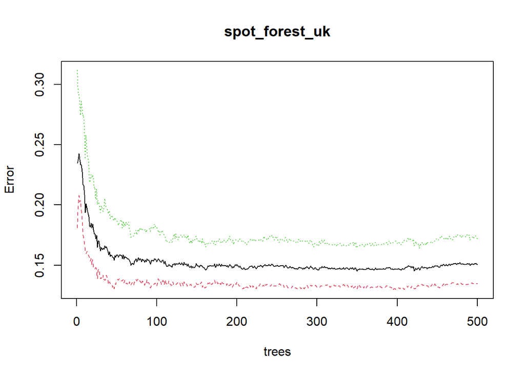

```r
spot_forest_uk <- randomForest(as.factor(target) ~ ., data = spot_train_uk)

plot(spot_forest_uk)
```

```r
summary(spot_forest_uk)
```

```
##                 Length Class  Mode
## call               3   -none- call
## type               1   -none- character
## predicted       2420   factor numeric
## err.rate        1500   -none- numeric
## confusion          6   -none- numeric
## votes           4840   matrix numeric
## oob.times       2420   -none- numeric
## classes            2   -none- character
## importance        15   -none- numeric
## importanceSD       0   -none- NULL
## localImportance    0   -none- NULL
## proximity          0   -none- NULL
## ntree              1   -none- numeric
## mtry               1   -none- numeric
## forest            14   -none- list
## y               2420   factor numeric
## test               0   -none- NULL
## inbag              0   -none- NULL
## terms              3   terms  call
```

### 2.9.1 Predict and Evaluate

```r
pred_forest_uk <- predict(spot_forest_uk, spot_test_uk)

library(caret)
confusionMatrix(as.factor(pred_forest_uk), as.factor(spot_test_uk$target), positive = "1")
```

```
## Confusion Matrix and Statistics
##
##           Reference
## Prediction    0    1
##          0 1256  193
##          1  185  786
##
##                Accuracy : 0.8438
##                  95% CI : (0.8287, 0.858)
##     No Information Rate : 0.5955
##     P-Value [Acc > NIR] : <2e-16
##
##                   Kappa : 0.6754
##
##  Mcnemar's Test P-Value : 0.7188
##
##             Sensitivity : 0.8029
##             Specificity : 0.8716
##          Pos Pred Value : 0.8095
##          Neg Pred Value : 0.8668
##              Prevalence : 0.4045
##          Detection Rate : 0.3248
##    Detection Prevalence : 0.4012
##       Balanced Accuracy : 0.8372
##
##        'Positive' Class : 1
##
```

**Random forest has the highest Kappa of any individual model at almost 68%.** Some trials reached as high as almost 70%.

## 2.10 Combine Models

```r
pred_comb_uk <- data.frame(pred_lr_uk, model_knn_uk, pred_ann_uk, pred_tree_uk, pred_forest_uk, spot_test_uk$target)

str(pred_comb_uk)
```

```
## 'data.frame':    2420 obs. of  6 variables:
##  $ pred_lr_uk         : num  0.637438 0.884896 0.266335 0.128679 0.000321 ...
##  $ model_knn_uk       : Factor w/ 2 levels "0","1": 2 2 1 1 1 1 2 1 2 2 ...
##  $ pred_ann_uk        : num  0.7299 0.8611 0.0874 0.0347 0.0221 ...
##  $ pred_tree_uk       : Factor w/ 2 levels "0","1": 2 2 1 1 1 1 2 1 2 1 ...
##  $ pred_forest_uk     : Factor w/ 2 levels "0","1": 2 2 1 1 1 1 2 1 2 2 ...
##  $ spot_test_uk.target: num  1 1 0 0 0 0 1 0 1 0 ...
```

```r
summary(pred_comb_uk)
```

```
##    pred_lr_uk      model_knn_uk  pred_ann_uk      pred_tree_uk pred_forest_uk
##  Min.   :0.00000   0:1196       Min.   :0.02214   0:1419       0:1449
##  1st Qu.:0.03176   1:1224       1st Qu.:0.02214   1:1001       1: 971
##  Median :0.41037                Median :0.39727
##  Mean   :0.40381                Mean   :0.40601
##  3rd Qu.:0.70644                3rd Qu.:0.78078
##  Max.   :0.99297                Max.   :0.86946
##  spot_test_uk.target
##  Min.   :0.0000
##  1st Qu.:0.0000
##  Median :0.0000
##  Mean   :0.4045
##  3rd Qu.:1.0000
##  Max.   :1.0000
```

### 2.10.1 New Test and Train Data Sets

```r
set.seed(13090890)
test_set_comb <- sample(1:nrow(pred_comb_uk), 0.3*nrow(pred_comb_uk))

spot_test_comb <- pred_comb_uk[test_set_comb, ]
spot_train_comb <- pred_comb_uk[-test_set_comb, ]
```

## 2.11 Build Stacked Model

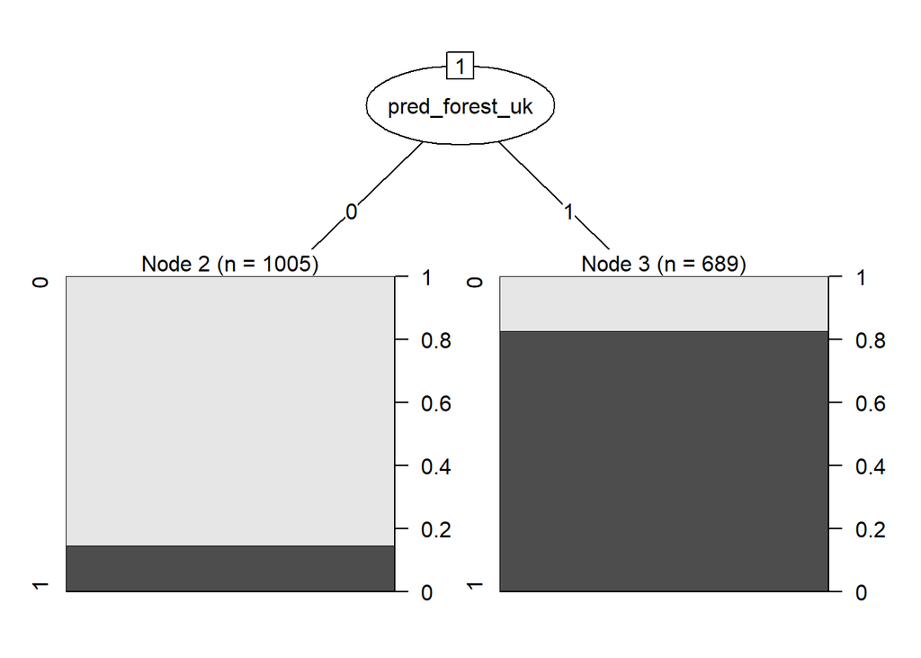

```r
library(C50)
spot_tree_comb <- C5.0(as.factor(spot_test_uk.target) ~ ., data = spot_train_comb)

plot(spot_tree_comb)
```

```r
summary(spot_tree_comb)
```

```
##
## Call:
## C5.0.formula(formula = as.factor(spot_test_uk.target) ~ ., data
##  = spot_train_comb)
##
##
## C5.0 [Release 2.07 GPL Edition]      Sun Apr 16 12:40:35 2023
## -------------------------------
##
## Class specified by attribute `outcome'
##
## Read 1694 cases (6 attributes) from undefined.data
##
## Decision tree:
##
## pred_forest_uk = 0: 0 (1005/147)
## pred_forest_uk = 1: 1 (689/120)
##
##
## Evaluation on training data (1694 cases):
##
##      Decision Tree
##    ----------------
##    Size      Errors
##
##       2  267(15.8%)   <<
##
##
##     (a)   (b)    <-classified as
##    ----  ----
##     858   120    (a): class 0
##     147   569    (b): class 1
##
##
##  Attribute usage:
##
##  100.00% pred_forest_uk
##
##
## Time: 0.0 secs
```

The stacked-model decision tree is telling us the following:

If the Random Forest model predicts a song will be a hit, the stacked model will predict it will be a hit; otherwise, it will not. Nothing matters other than the random forest.

### 2.11.1 Predict and Evaluate

```r
pred_tree_comb <- predict(spot_tree_comb, spot_test_comb)

library(caret)
confusionMatrix(as.factor(pred_tree_comb), as.factor(spot_test_comb$spot_test_uk.target), positive = "1")
```

```
## Confusion Matrix and Statistics
##
##           Reference
## Prediction   0   1
##          0 398  46
##          1  65 217
##
##                Accuracy : 0.8471
##                  95% CI : (0.8188, 0.8725)
##     No Information Rate : 0.6377
##     P-Value [Acc > NIR] : < 2e-16
##
##                   Kappa : 0.6742
##
##  Mcnemar's Test P-Value : 0.08755
##
##             Sensitivity : 0.8251
##             Specificity : 0.8596
##          Pos Pred Value : 0.7695
##          Neg Pred Value : 0.8964
##              Prevalence : 0.3623
##          Detection Rate : 0.2989
##    Detection Prevalence : 0.3884
##       Balanced Accuracy : 0.8424
##
##        'Positive' Class : 1
##
```

## 2.12 Incorporate Cost Matrix

There are approximately the same number of false negatives and false positives in the prediction.

A false positive in this case represents songs we predict will be hits but they flop. The loss here is the amount of money invested in the production of these songs and the reputation hit from having recommended their production. Even though the average cost to produce a song is only approx. $2.5K, this is bare minimum. Add in all the marketing and other support money, and the reputational damage if a promoted song fails, and this could result in a substantial loss. We want to minimize these errors.

A false negative in this case represents songs we predict will be flops but they ultimately become hits. The loss here is an opportunity cost – the result of a decision not taken. While a massive hit can produce a lot of money for those involved, as Sanjeev says, nobody’s ever been fired for that kind of mistake. While not ideal, we’d prefer these mistakes to up-front financial losses.

We estimate a false positive is twice as damaging as a false negative.

```r
error_cost <- matrix(c(0, 2, 1, 0), nrow = 2)
error_cost
```

```
##      [,1] [,2]
## [1,]    0    1
## [2,]    2    0
```

```r
model_error_uk <- C5.0(as.factor(spot_test_uk.target) ~ ., data = spot_train_comb, costs = error_cost)
pred_error_uk <- predict(model_error_uk, spot_test_comb)

confusionMatrix(as.factor(pred_error_uk), as.factor(spot_test_comb$spot_test_uk.target), positive = "1")
```

```
## Confusion Matrix and Statistics
##
##           Reference
## Prediction   0   1
##          0 407  60
##          1  56 203
##
##                Accuracy : 0.8402
##                  95% CI : (0.8115, 0.8661)
##     No Information Rate : 0.6377
##     P-Value [Acc > NIR] : <2e-16
##
##                   Kappa : 0.6531
##
##  Mcnemar's Test P-Value : 0.7806
##
##             Sensitivity : 0.7719
##             Specificity : 0.8790
##          Pos Pred Value : 0.7838
##          Neg Pred Value : 0.8715
##              Prevalence : 0.3623
##          Detection Rate : 0.2796
##    Detection Prevalence : 0.3567
##       Balanced Accuracy : 0.8255
##
##        'Positive' Class : 1
##
```

The Kappa of the stacked model has been reduced slightly, to around 65-66%, but this is still very strong. However, we also ran trials in which we assumed a much heavier cost to false positives, and unfortunately the Kappa dropped substantially to around 45%. A larger the negative impact of one error type vs. the other would make us less confident in using this model to predict song success.

## 2.13 Conclusion

Given the highly competitive nature of the music industry, with artists coming from all sources such as TikTok, Youtube, Spotify, etc., it is crucial that record labels are able to find and identify these young talents in a cost efficient manner. Our team believes we can help both artists and record labels alike to use these models to cut through some of the noise and identify hits efficiently and effectively.